# What is the performance impact of students missing school?

In this notebook, I will attempt to identify the performance impact of students missing school. I will use public data sourced from the [NJ DOE](https://www.nj.gov/education/data/). As schools deal with Covid-19, there is a chance of students missing days of school as schools cycle through shut-downs, distant learning, and reopening. In doing this, there is a real risk of students seeing a reduction in performance. The focus will be on elementary schools in aim to set up our students for continued success in secondary education and beyond. These students are also particularly inexperienced with distance learning.

# Table of Contents

## Collect and Clean Data

```python
import os
import pandas as pd
from numbers import Number
import matplotlib.pyplot as plt
import seaborn as sns

path = "C:\\Users\\allis\\Documents\\IndependentProjects\\NJ_School_Success"
os.chdir(path)
```

### Data Source

The NJ DOE provides data on student performance [on their website](https://rc.doe.state.nj.us/ReportsDatabase.aspx), which covers basic demographics, general school information, student attendance, and student performance on statewide assessments . I will use this as the primary source of data.

```python
# Loads the entire excel file - this will take a while. Be patient...
NJDOE_perf_20182019 = pd.ExcelFile("PerformanceReports_20182019.xlsx")
```

Scrolling through this Excel file, I noticed that the values used to represent "NA" vary across sheets, sometimes being denoted by "*", "NA", "N", "**", or other values. Here I write a little helper function to use when trying to identify what are the non-numeric values in a column. As well as a function to easily replace those values.

```python
def identify_nulls(df, cols_to_check):
    ''' Takes a dataframe and list of column names and returns a set of the non-numeric values in column '''
    null_vals = set()
    for col_name in cols_to_check:
        col_series = df[col_name]
        for value in col_series.values:
            if isinstance(value, Number) == False:
                if value.replace('.','').isdigit() == False:
                    null_vals.add(value)
    return null_vals


def replace_nulls(df, cols_to_replace, null_vals, replace_val):
    ''' Takes a dataframe, list of columns to replace, all the values to replace, and the replacement value and returns a modified dataframe'''
    for col_name in cols_to_replace:
        df[col_name].replace(list(null_vals), replace_val, inplace=True)
```

Our schools of interest are elementary and middle schools, where this data file contains pre-k through secondary education. Therefore we will downselect to only the schools of interest.

```python
all_schools = pd.read_excel(NJDOE_perf_20182019, sheet_name="EnrollmentTrendsbyGrade",
                         converters={'CountyCode':str,'DistrictCode':str,'SchoolCode':str})
all_schools.head(1)
```

|  | CountyCode | CountyName | DistrictCode | DistrictName | SchoolCode | SchoolName | GradePK | GradeKG | Grade01 | Grade02 | ... | Grade04 | Grade05 | Grade06 | Grade07 | Grade08 | Grade09 | Grade10 | Grade11 | Grade12 | Total |
| --- | --- | --- | --- | --- | --- | --- | --- | --- | --- | --- | --- | --- | --- | --- | --- | --- | --- | --- | --- | --- | --- |
| 0 | 01 | Atlantic | 0010 | Absecon Public Schools District | 050 | Emma C Attales | 0 | 0 | 0 | 0 | ... | 0 | 106 | 96 | 95 | 80 | 0 | 0 | 0 | 0 | 377 |

1 rows × 21 columns

The NJSLA begins in Grade 3. We are only interested in Grades 3 through 8.

```python
# Find and replace the null values in the columns of interest
cols_to_use = ["Grade03", "Grade04", "Grade05", "Grade06", "Grade07", "Grade08"]
null_vals = identify_nulls(all_schools,cols_to_use)
replace_nulls(all_schools,cols_to_use, null_vals, 0)

# Sum of students in grades of interest
all_schools['Sum_Students'] = all_schools.Grade03 + all_schools.Grade04 + all_schools.Grade05 +  \
                              all_schools.Grade06 + all_schools.Grade07 + all_schools.Grade08
all_schools.Sum_Students = pd.to_numeric(all_schools.Sum_Students)

# Schools of interest have students in Grade 3 through 8
schools = all_schools.loc[all_schools.Sum_Students > 0].copy()
schools.drop(["GradePK","GradeKG","Grade01", "Grade02", "Grade09","Grade10", "Grade11","Grade11","Grade12"], axis=1, inplace=True)

# Create a unique code for each school from component codes
schools['UniqueCode'] = schools.CountyCode + schools.DistrictCode + schools.SchoolCode

print(f"There are {schools.shape[0]} schools hosting students in Grades 3-8 in NJ for 2018-2019")
schools.head(5)
```

```
There are 1896 schools hosting students in Grades 3-8 in NJ for 2018-2019
```

|  | CountyCode | CountyName | DistrictCode | DistrictName | SchoolCode | SchoolName | Grade03 | Grade04 | Grade05 | Grade06 | Grade07 | Grade08 | Total | Sum_Students | UniqueCode |
| --- | --- | --- | --- | --- | --- | --- | --- | --- | --- | --- | --- | --- | --- | --- | --- |
| 0 | 01 | Atlantic | 0010 | Absecon Public Schools District | 050 | Emma C Attales | 0 | 0 | 106 | 96 | 95 | 80 | 377 | 377 | 010010050 |
| 1 | 01 | Atlantic | 0010 | Absecon Public Schools District | 060 | H Ashton Marsh | 82 | 86 | 0 | 0 | 0 | 0 | 490 | 168 | 010010060 |
| 3 | 01 | Atlantic | 0110 | Atlantic City School District | 030 | Sovereign Avenue School | 68 | 79 | 91 | 95 | 84 | 78 | 730 | 495 | 010110030 |
| 4 | 01 | Atlantic | 0110 | Atlantic City School District | 050 | Chelsea Heights School | 36 | 35 | 28 | 36 | 51 | 28 | 371 | 214 | 010110050 |
| 5 | 01 | Atlantic | 0110 | Atlantic City School District | 060 | Texas Avenue School | 63 | 47 | 51 | 72 | 75 | 66 | 534 | 374 | 010110060 |

There are many different sheets in the source data file that we will be calling and selecting school data. Let us write another helper function that will reduce any future dataframe to only include those schools of interest.

```python
def reduce_schools(df_reduce, df_schools = schools):
    ''' Take two dataframes: one with all source data that is to be reduced, and the second with schools to keep.
        Merge dataframes so that only schools of interest are kept. '''
    # Count rows and columns
    r_i, c_i = df_reduce.shape

    # Create a unique identifier code for each school from component codes
    df_reduce['UniqueCode'] = df_reduce.CountyCode + df_reduce.DistrictCode + df_reduce.SchoolCode

    # Merge on the unique code, use inner merge to only keep shared keys (schools)
    df_reduce = df_reduce.merge(df_schools['UniqueCode'],how="inner",on="UniqueCode")

    # Count rows and columns
    r_o, c_o = df_reduce.shape

    print(f'Dataframe has been changed from {r_i} to {r_o} rows.')
    return df_reduce
```

### Measures of Performance

Browsing the [Reference Guide](https://rc.doe.state.nj.us/Documents/1819/ReferenceGuide.pdf) for the performance data downladed from NJ DOE, we have access to the following metrics that we might be able to use as measures of success:

| Table Name | Metric | Description |
| --- | --- | --- |
| NJSLAScience | % Students Met Level X | The NJSLA-S measures student proficiency with the New Jersey Student Learning Standards for Science. All students in grades 5, 8, and 11 take the NJSLA-S assessment. The spring 2019 science administra… |
| MathPerformance | Average Scale Score and % Students Met Level X | For each student group and for the entire school, district, or state population, the table shows the number of valid scores, the mean scale scores, the percentage of students scoring at each performan… |
| ELAPerformance | Average Scale Score and % Students Met Level X | For each student group and for the entire school, district, or state population, the table shows the number of valid scores, the mean scale scores, the percentage of students scoring at each performan… |

This Score Guide[(ELA/Math)](https://nj.mypearsonsupport.com/resources/reporting/NJSLA-ELA&Math_Score_Guide_Spr19.pdf)[(Science)](https://measinc-nj-science.com/sites/default/files/2020-02/2020_01_16_NJSLA-S%20Score%20Interpretation%20Guide.pdf) goes into greater detail on how to interpret the score values. Note that non-numeric values are identifed by:

| * | indicates that data was available for too few students to report the given information, or the data represents a small percentage of students. There may be some additional cases where the data was kep… |
| --- | --- |
| ** | indicates that data was not available for the minimum 20 students, the required number for a student group to be included in New Jersey’s Every Student Succeeds Act (ESSA) accountability system. This … |
| N | indicates that no data was available to report. This happens when there are no students enrolled in a particular student group or if no data was submitted by the district. |

```python
# Create dataframe for each table listed above
perf_science = pd.read_excel(NJDOE_perf_20182019, sheet_name="NJSLAScienceTable",
                         converters={'CountyCode':str,'DistrictCode':str,'SchoolCode':str})

perf_math = pd.read_excel(NJDOE_perf_20182019, sheet_name="MathPerformanceByGradeTest",
                         converters={'CountyCode':str,'DistrictCode':str,'SchoolCode':str})

perf_ELA = pd.read_excel(NJDOE_perf_20182019, sheet_name="ELALiteracyPerformanceByGrade",
                         converters={'CountyCode':str,'DistrictCode':str,'SchoolCode':str})
```

#### Data cleaning: perf_science

```python
# Reduce to schools of interest
perf_science = reduce_schools(perf_science)

# Reduce to grades of interest
perf_science = perf_science[perf_science.Grade.isin(['5','8'])]
perf_science.replace(to_replace={'Grade': {5: 'Grade 05', 8: 'Grade 08'}}, inplace=True)

# View sample
perf_science.sample(3, random_state=8)
```

```
Dataframe has been changed from 45923 to 38779 rows.
```

|  | CountyCode | CountyName | DistrictCode | DistrictName | SchoolCode | SchoolName | Grade | Student Group | LEVEL_1 | LEVEL_2 | LEVEL_3 | LEVEL_4 | UniqueCode |
| --- | --- | --- | --- | --- | --- | --- | --- | --- | --- | --- | --- | --- | --- |
| 37331 | 80 | Charters | 6105 | Hudson Arts and Science Charter School | 996 | Hudson Arts and Science Charter School | Grade 05 | Homeless Students | N | N | N | N | 806105996 |
| 20475 | 23 | Middlesex | 3150 | Middlesex County Vocational and Technical Scho... | 070 | Middlesex County Voc Acad Allied Health & Biom... | Grade 08 | Students without Disabilities | N | N | N | N | 233150070 |
| 9583 | 09 | Cape May | 3130 | Middle Township Public School District | 085 | Middle Township Elementary #2 | Grade 05 | Female | 40 | 43 | 17 | 0 | 093130085 |

```python
# Convert numeric columns of interest into numeric data types, handle non-numeric values by coercing to NaN's
cols_to_use = ["LEVEL_1", "LEVEL_2", "LEVEL_3", "LEVEL_4"]
perf_science[cols_to_use] = perf_science[cols_to_use].apply(pd.to_numeric, errors='coerce')

# Create a MetExceed Column to represent the total % of students meeting proficiency
perf_science['MetExceed'] =perf_science.LEVEL_3 + perf_science.LEVEL_4

# Reduce to only schoolwide groups, as AbsentData only availabe schoolwide
perf_science = perf_science[perf_science['Student Group'] == 'Schoolwide']

# Remove Na's - usually due to small or non-existent sample size
perf_science.dropna(subset=['MetExceed'], inplace=True)

# Remove cols no longer needed
perf_science.drop(['CountyCode','CountyName','DistrictCode','DistrictName','SchoolCode','SchoolName','Student Group',
                  'LEVEL_1','LEVEL_2','LEVEL_3','LEVEL_4'],axis=1,inplace=True)

# View sample
perf_science.sample(3, random_state=8)
```

|  | Grade | UniqueCode | MetExceed |
| --- | --- | --- | --- |
| 23674 | Grade 05 | 253160060 | 29.0 |
| 6935 | Grade 05 | 070150050 | 27.0 |
| 23560 | Grade 05 | 253030070 | 55.0 |

#### Data cleaning: perf_math

```python
# Reduce to schools of interest
perf_math = reduce_schools(perf_math)

# Reduce to grades of interest
perf_math = perf_math[perf_math.Grade.isin(['Grade 03', 'Grade 04', 'Grade 05', 'Grade 06', 'Grade 07', 'Grade 08'])]

# View sample
perf_math.sample(3, random_state=6)
```

```
Dataframe has been changed from 163096 to 141436 rows.
```

|  | CountyCode | CountyName | DistrictCode | DistrictName | SchoolCode | SchoolName | Grade | Student Group | ValidScores | MeanScore | DistrictMean | LEVEL_1 | LEVEL_2 | LEVEL_3 | LEVEL_4 | LEVEL_5 | MetExceed | StateMean | StateMet_Exceed | UniqueCode |
| --- | --- | --- | --- | --- | --- | --- | --- | --- | --- | --- | --- | --- | --- | --- | --- | --- | --- | --- | --- | --- |
| 69731 | 21 | Mercer | 2580 | Lawrence Township Public School District | 085 | Lawrence Intermediate School | Grade 04 | Asian, Native Hawaiian, or Pacific Islander | 49 | 761 | 761 | * | * | 20 | * | * | 69 | 776 | 82 | 212580085 |
| 139948 | 80 | Charters | 7720 | Red Bank Charter School | 915 | Red Bank Charter School | Grade 08 | Schoolwide | * | * | * | * | * | * | * | * | * | 728 | 29 | 807720915 |
| 140456 | 80 | Charters | 7830 | Soaraing Heights Charter School | 980 | Soaring Heights Charter School | Grade 05 | Male | * | * | * | * | * | * | * | * | * | 747 | 47 | 807830980 |

```python
# Convert numeric columns of interest into numeric data types, handle non-numeric values by coercing to NaN's
cols_to_use = ["ValidScores", "MeanScore","DistrictMean", "LEVEL_1", "LEVEL_2", "LEVEL_3", "LEVEL_4", "LEVEL_5", "MetExceed", "StateMean", "StateMet_Exceed"]
perf_math[cols_to_use] = perf_math[cols_to_use].apply(pd.to_numeric, errors='coerce')

# Reduce to only schoolwide groups, as AbsentData only availabe schoolwide
perf_math = perf_math[perf_math['Student Group'] == 'Schoolwide']

# Remove Na's - usually due to small or non-existent sample size
perf_math.dropna(subset=['MetExceed'], inplace=True)

# Remove cols no longer needed
perf_math.drop(['CountyCode','CountyName','DistrictCode','DistrictName','SchoolCode','SchoolName','Student Group', 'ValidScores',
              'MeanScore','LEVEL_1','LEVEL_2','LEVEL_3','LEVEL_4','LEVEL_5','DistrictMean','StateMean','StateMet_Exceed'],axis=1,inplace=True)
# View sample
perf_math.sample(3, random_state=6)
```

|  | Grade | MetExceed | UniqueCode |
| --- | --- | --- | --- |
| 112721 | Grade 07 | 86.0 | 333860010 |
| 77248 | Grade 04 | 41.0 | 234090145 |
| 95545 | Grade 08 | 77.0 | 274000030 |

#### Data cleaning: perf_ELA

```python
# Reduce to schools of interest
perf_ELA = reduce_schools(perf_ELA)

# Reduce to Grades of interest
perf_ELA = perf_ELA[perf_ELA.Grade.isin(['Grade 03', 'Grade 04', 'Grade 05', 'Grade 06', 'Grade 07', 'Grade 08'])]

# View sample
perf_ELA.sample(3, random_state=15)
```

```
Dataframe has been changed from 135945 to 121524 rows.
```

|  | CountyCode | CountyName | DistrictCode | DistrictName | SchoolCode | SchoolName | Grade | Student Group | ValidScores | MeanScore | DistrictMean | LEVEL_1 | LEVEL_2 | LEVEL_3 | LEVEL_4 | LEVEL_5 | MetExceed | StateMean | StateMet_Exceed | UniqueCode |
| --- | --- | --- | --- | --- | --- | --- | --- | --- | --- | --- | --- | --- | --- | --- | --- | --- | --- | --- | --- | --- |
| 60742 | 21 | Mercer | 5210 | Trenton Public School District | 200 | Grant Elementary School | Grade 05 | White | * | * | 714 | * | * | * | * | * | * | 764 | 68 | 215210200 |
| 54635 | 17 | Hudson | 5240 | Union City School District | 120 | George Washington Elementary School | Grade 06 | Military-Connected Students | N | N | N | N | N | N | N | N | N | 753 | 54 | 175240120 |
| 56179 | 19 | Hunterdon | 0920 | Clinton Township School District | 040 | Round Valley | Grade 04 | Students with Disabilities | 29 | 739 | 739 | * | * | * | 48 | 0 | 48 | 725 | 25 | 190920040 |

```python
# Convert numeric columns of interest into numeric data types, handle non-numeric values by coercing to NaN's
cols_to_use = ["ValidScores", "MeanScore","DistrictMean", "LEVEL_1", "LEVEL_2", "LEVEL_3", "LEVEL_4", "LEVEL_5", "MetExceed", "StateMean", "StateMet_Exceed"]
perf_ELA[cols_to_use] = perf_ELA[cols_to_use].apply(pd.to_numeric, errors='coerce')

# Reduce to only schoolwide groups, as AbsentData only availabe schoolwide
perf_ELA = perf_ELA[perf_ELA['Student Group'] == 'Schoolwide']

# Remove Na's - usually due to small or non-existent sample size
perf_ELA.dropna(subset=['MetExceed'], inplace=True)

# Remove cols no longer needed
perf_ELA.drop(['CountyCode','CountyName','DistrictCode','DistrictName','SchoolCode','SchoolName','Student Group', 'ValidScores',
              'MeanScore','DistrictMean','LEVEL_1','LEVEL_2','LEVEL_3','LEVEL_4','LEVEL_5','StateMean','StateMet_Exceed'],axis=1,inplace=True)

# View sample
perf_ELA.sample(3, random_state=15)
```

|  | Grade | MetExceed | UniqueCode |
| --- | --- | --- | --- |
| 68812 | Grade 04 | 44.0 | 235850100 |
| 5713 | Grade 08 | 62.0 | 031230040 |
| 33928 | Grade 05 | 46.0 | 130250080 |

```python
merged_df = perf_science.merge(perf_ELA, how="outer",on=['Grade','UniqueCode'],suffixes=('_science','_ELA'))
merged_df = merged_df.merge(perf_math, how="outer", on=['Grade','UniqueCode'])
merged_df.rename({'MetExceed_science':'Science','MetExceed_ELA':'ELA','MetExceed':'Math'},axis=1,inplace=True)

merged_df.head(3)
```

|  | Grade | UniqueCode | Science | ELA | Math |
| --- | --- | --- | --- | --- | --- |
| 0 | Grade 05 | 010010050 | 36.0 | 51.0 | 45.0 |
| 1 | Grade 08 | 010010050 | 24.0 | 60.0 | 40.0 |
| 2 | Grade 05 | 010110030 | 10.0 | 37.0 | 25.0 |

### Contributing Factors

Browsing the [Reference Guide](https://rc.doe.state.nj.us/Documents/1819/ReferenceGuide.pdf) for the performance data downladed from NJ DOE, we have access to the following metrics that we might be able to use as to assess effect of absence on students:

| Table Name | Metric | Description |
| --- | --- | --- |
| DaysAbsent | % Students absent X number of days | The “Days Absent” graph (Figure 52) displays the schoolwide percentage of students in grades K through 12 by the number of days they were absent during the reported year. |
| FacultyAttendance | % Days Faculty were Present | To calculate faculty attendance, the sum of faculty days present is divided by the sum of faculty days possible. Approved professional days, personal days, staff training days, bereavement days, jury … |

```python
# Create dataframe for each table listed above
absent_students = pd.read_excel(NJDOE_perf_20182019, sheet_name="DaysAbsent",
                         converters={'CountyCode':str,'DistrictCode':str,'SchoolCode':str})

absent_faculty = pd.read_excel(NJDOE_perf_20182019, sheet_name="FacultyAttendance",
                         converters={'CountyCode':str,'DistrictCode':str,'SchoolCode':str})
```

#### Data cleaning: absent_students

```python
# Reduce to schools of interest
absent_students = reduce_schools(absent_students)

# View sample
absent_students.sample(3, random_state=14)
```

```
Dataframe has been changed from 2374 to 1846 rows.
```

|  | CountyCode | CountyName | DistrictCode | DistrictName | SchoolCode | SchoolName | Abs_0 | Abs_1-5 | Abs_6-10 | Abs_11-15 | Abs_over15 | UniqueCode |
| --- | --- | --- | --- | --- | --- | --- | --- | --- | --- | --- | --- | --- |
| 626 | 13 | Essex | 3570 | Newark Public School District | 415 | Dr. E. Alma Flagg School | 2 | 20 | 23 | 20 | 34 | 133570415 |
| 397 | 07 | Camden | 1720 | Gibbsboro Elementary School District | 020 | Gibbsboro Elementary School | 0 | 27 | 37 | 23 | 12 | 071720020 |
| 358 | 07 | Camden | 0340 | Berlin Township School District | 030 | Dwight D Eisenhower Middle School | 3 | 35 | 31 | 15 | 15 | 070340030 |

```python
# Remove NA's from absent_students
cols_to_use = ["Abs_0", "Abs_1-5","Abs_6-10", "Abs_11-15", "Abs_over15"]
absent_students[cols_to_use] = absent_students[cols_to_use].apply(pd.to_numeric, errors='coerce')

# Remove Na's - usually due to small or non-existent sample size
absent_students.dropna(subset=['Abs_1-5'], inplace=True)

# View sample
absent_students.sample(3, random_state=14)
```

|  | CountyCode | CountyName | DistrictCode | DistrictName | SchoolCode | SchoolName | Abs_0 | Abs_1-5 | Abs_6-10 | Abs_11-15 | Abs_over15 | UniqueCode |
| --- | --- | --- | --- | --- | --- | --- | --- | --- | --- | --- | --- | --- |
| 626 | 13 | Essex | 3570 | Newark Public School District | 415 | Dr. E. Alma Flagg School | 2 | 20 | 23 | 20 | 34 | 133570415 |
| 397 | 07 | Camden | 1720 | Gibbsboro Elementary School District | 020 | Gibbsboro Elementary School | 0 | 27 | 37 | 23 | 12 | 071720020 |
| 358 | 07 | Camden | 0340 | Berlin Township School District | 030 | Dwight D Eisenhower Middle School | 3 | 35 | 31 | 15 | 15 | 070340030 |

#### Data cleaning: absent_faculty

```python
# Reduce to schools of interest
absent_faculty = reduce_schools(absent_faculty)

# View sample
absent_faculty.sample(3, random_state=37)
```

```
Dataframe has been changed from 2510 to 1896 rows.
```

|  | CountyCode | CountyName | DistrictCode | DistrictName | SchoolCode | SchoolName | PercentDaysPresent | UniqueCode |
| --- | --- | --- | --- | --- | --- | --- | --- | --- |
| 1866 | 80 | Charters | 6635 | Greater Brunswick Charter School | 930 | Greater Brunswick Charter School | 96.2 | 806635930 |
| 1298 | 27 | Morris | 3364 | Educational Services Commission of Morris County | 080 | Park Lake School | N | 273364080 |
| 1084 | 23 | Middlesex | 4860 | South Brunswick School District | 060 | Cambridge Elementary School | 96.7 | 234860060 |

```python
# Remove NA's from absent_students
cols_to_use = ["PercentDaysPresent"]
absent_faculty[cols_to_use] = absent_faculty[cols_to_use].apply(pd.to_numeric, errors='coerce')

# Remove Na's - usually due to small or non-existent sample size
absent_faculty.dropna(subset=['PercentDaysPresent'], inplace=True)

# View sample
absent_faculty.sample(3, random_state=37)
```

|  | CountyCode | CountyName | DistrictCode | DistrictName | SchoolCode | SchoolName | PercentDaysPresent | UniqueCode |
| --- | --- | --- | --- | --- | --- | --- | --- | --- |
| 1653 | 37 | Sussex | 3590 | Newton Public School District | 060 | Halsted Middle School | 91.9 | 373590060 |
| 1414 | 29 | Ocean | 4105 | Pinelands Regional School District | 060 | Pinelands Regional Jr. High School | 96.5 | 294105060 |
| 1455 | 31 | Passaic | 0900 | Clifton Public School District | 190 | School #14 | 96.7 | 310900190 |

## Data Exploration

```python
font = {'family' : 'Arial',
        'weight' : 'normal',
        'size'   : 20}

plt.rc('font', **font)
```

First let us take a peak at the enrollment trends. First a count of schools that host students in each grade:

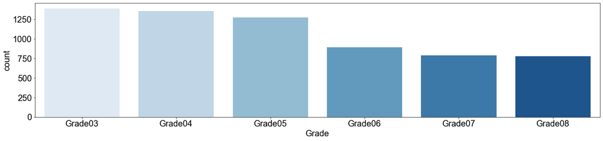

```python
# Reformat the schools dataframe
schools_melt = schools.melt(id_vars=['UniqueCode'],value_vars=['Grade03','Grade04', 'Grade05', 'Grade06', 'Grade07', 'Grade08'],
                            var_name='Grade',value_name='NumStudents')
schools_melt = schools_melt[schools_melt.NumStudents > 0]

# Initialize matplotlib figure
fig = plt.figure(figsize=(20, 5), tight_layout=True)

# Create a countplot of schools with students in each grade
sns.countplot(x= "Grade",
            data=schools_melt,
            order = ['Grade03', 'Grade04', 'Grade05', 'Grade06', 'Grade07', 'Grade08'],
            orient="v",
            palette="Blues")
```

Now we will look at the number of students enrolled at each school:

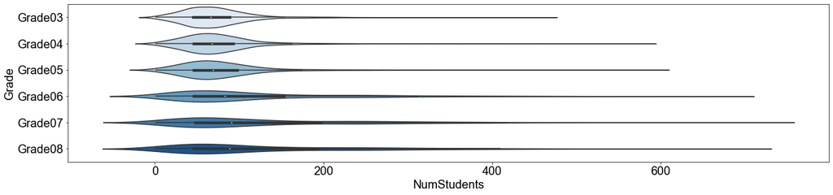

```python
# Initialize matplotlib figure
fig = plt.figure(figsize=(20, 5), tight_layout=True)

# Plot number of students in each grade per school
sns.violinplot(x='NumStudents',y='Grade',
            data=schools_melt,
            orient="h",
           palette="Blues")
```

As students advance in grade they see a much larger variation in class size, trending towards larger class sizes consolidated in a fewer number of schools.

Next we will get an idea of how students perform on these assessments.

```python
# Reformat the assessment scores dataframes to be easier to plot
melted_df = merged_df.melt(['Grade','UniqueCode'],
                           var_name='MetExceed', value_name='PercentMetExceed')
melted_df.rename({'MetExceed':'Subject'}, axis=1,inplace=True)
abs_stu_melt = absent_students.melt(id_vars = ['UniqueCode'],
                                    value_vars = ['Abs_0','Abs_1-5','Abs_6-10','Abs_11-15','Abs_over15'],
                                    var_name = 'NumDaysAbsent', value_name = 'PercentStudentBody')
melted_df = melted_df.merge(abs_stu_melt,how='left',on='UniqueCode')
melted_df = melted_df.merge(absent_faculty[["PercentDaysPresent", "UniqueCode"]],how='left',on='UniqueCode')

melted_df.rename({'MetExceed':'Subject', 'PercentDaysPresent':'PercentDaysFacultyPresent'}, axis=1,inplace=True)
melted_df.head()
```

|  | Grade | UniqueCode | Subject | PercentMetExceed | NumDaysAbsent | PercentStudentBody | PercentDaysFacultyPresent |
| --- | --- | --- | --- | --- | --- | --- | --- |
| 0 | Grade 05 | 010010050 | Science | 36.0 | Abs_0 | 6 | 97.9 |
| 1 | Grade 05 | 010010050 | Science | 36.0 | Abs_1-5 | 44 | 97.9 |
| 2 | Grade 05 | 010010050 | Science | 36.0 | Abs_6-10 | 28 | 97.9 |
| 3 | Grade 05 | 010010050 | Science | 36.0 | Abs_11-15 | 13 | 97.9 |
| 4 | Grade 05 | 010010050 | Science | 36.0 | Abs_over15 | 10 | 97.9 |

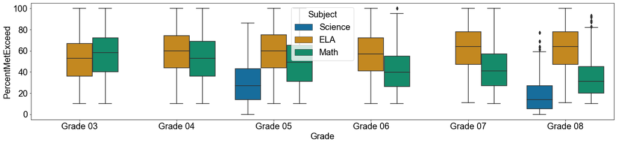

```python
# Initialize matplotlib figure and subplots
fig = plt.figure(figsize=(20, 5), tight_layout=True)

# Extract boxplot from each dataframe containing performance data
sns.boxplot(y="PercentMetExceed", x= "Grade",
            hue="Subject",
            data=melted_df,
            order = ['Grade 03', 'Grade 04', 'Grade 05', 'Grade 06', 'Grade 07', 'Grade 08'],
            orient="v",
            palette="colorblind")
```

Unfortunately the percentage of students who meet science and math expectations is below 50% for Grades 5 and above. It should be noted that the NJSLA-S test, which assesses Science, was a new assessment for 2019.

## Primary Analysis

### Grade 3

We extract only values from Grade 3 students. Then we look at the percent of students meeting or exceeding expectations versus the percent of the student body for that school in each "Number of Days Absent" category.

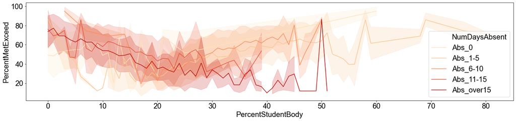

```python
# Initialize matplotlib figure and subplots
fig = plt.figure(figsize=(20, 5), tight_layout=True)

sns.lineplot(x="PercentStudentBody",y="PercentMetExceed",
               hue="NumDaysAbsent",
              data= melted_df[melted_df.Grade == 'Grade 03'],
              palette="OrRd",
             ci="sd")
```

The data seems loosely related to the percent of students who are meeting expections. There appears to be the strongest relationship with schools with high percentage of their students with lots of absences doing poorly, and those with high percentage of their students with minimal absences doing well. However the standard deviation bands are pretty wide, suggesting a lot of scatter in our data. Let's run some regression lines to see

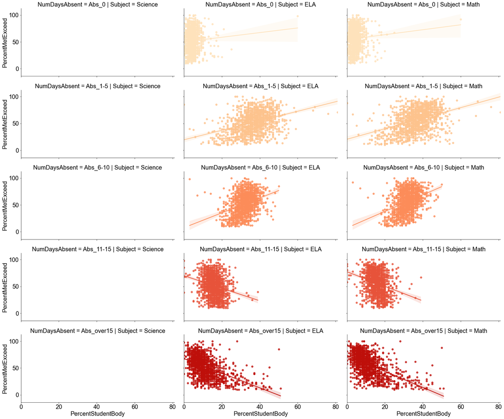

```python
sns.lmplot(x="PercentStudentBody",y="PercentMetExceed",row="NumDaysAbsent",col="Subject",
               hue="NumDaysAbsent",
              data= melted_df[melted_df.Grade == 'Grade 03'],
              palette="OrRd",
              height=4,
              aspect=2)
```

As expected, there is a lot of scatter in the data - meaning this variable is far from the most predictive/linearly related. It is highly likely other factors such as spending per pupil, average class size, and other resources make a large impact. Though we do see a rather reliable trend when it comes to high absences. The regression line follows the data for "Abs_over15" relatively well, especially for the Math subject.

```python
melted_df[(melted_df.Grade == 'Grade 03') & (melted_df.NumDaysAbsent == 'Abs_over15') & (melted_df.Subject=='Math')].corr(method='pearson')
```

|  | PercentMetExceed | PercentStudentBody | PercentDaysFacultyPresent |
| --- | --- | --- | --- |
| PercentMetExceed | 1.000000 | -0.553281 | 0.153515 |
| PercentStudentBody | -0.553281 | 1.000000 | -0.201869 |
| PercentDaysFacultyPresent | 0.153515 | -0.201869 | 1.000000 |

```python
melted_df[(melted_df.Grade == 'Grade 03') & (melted_df.NumDaysAbsent == 'Abs_over15') & (melted_df.Subject=='ELA')].corr(method='pearson')
```

|  | PercentMetExceed | PercentStudentBody | PercentDaysFacultyPresent |
| --- | --- | --- | --- |
| PercentMetExceed | 1.000000 | -0.512466 | 0.141795 |
| PercentStudentBody | -0.512466 | 1.000000 | -0.201869 |
| PercentDaysFacultyPresent | 0.141795 | -0.201869 | 1.000000 |

```python
# [TODO] Fix up correlation matrix for Grade 3 to show all categories (NumDays and Subjects), if possible
```

```python
# [TODO] Other grades
```

```python
# [TODO] Cleanup text, make axis fonts largers, review plot/axis titles for reader clarity
```